# 04 - Practice (8)

Autores/as

Yann Say

Laura Grave de Peralta

Gregory Maulet-Toucher

Fecha de publicación

25 de marzo de 2025

# Practica

## Practica 1

- Agregue el tema **IMPACT** al siguiente gráfico de barras `initialplot`.

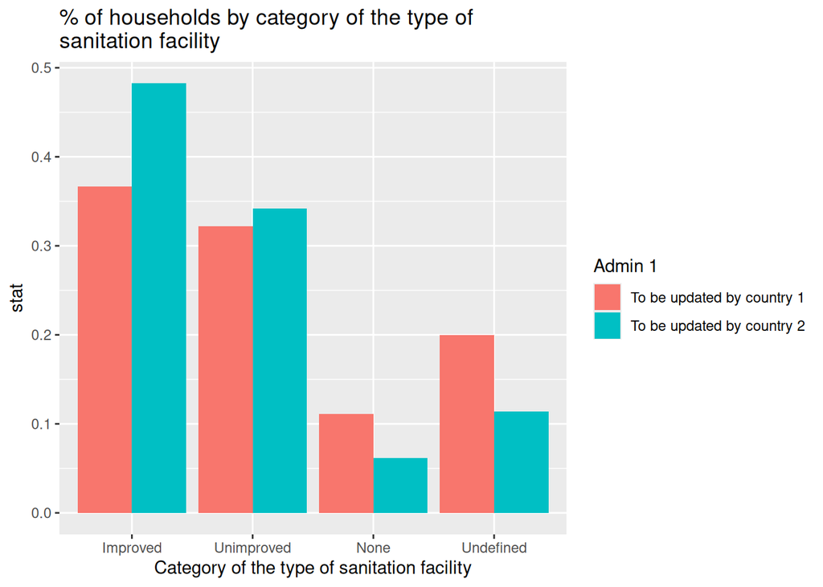

```r
library(presentresults)
library(dplyr)

data_to_plot <- presentresults::presentresults_MSNA2024_labelled_results_table |>
  dplyr::filter(
    analysis_var == "wash_sanitation_facility_cat",
    group_var == "admin1") |>
  dplyr::mutate(label_analysis_var_value = factor(label_analysis_var_value,
                                                  levels = c("Improved",
                                                             "Unimproved",
                                                             "None",
                                                             "Undefined")))
initialplot <- data_to_plot %>%
  ggplot2::ggplot() +
  ggplot2::geom_col(
    ggplot2::aes(
      x = label_analysis_var_value,
      y = stat,
      fill = label_group_var_value
    ),
    position = "dodge"
  ) +
  ggplot2::labs(
    title = stringr::str_wrap(unique(data_to_plot$indicator), 50),
    x = stringr::str_wrap(unique(data_to_plot$label_analysis_var), 50),
    fill = stringr::str_wrap(unique(data_to_plot$label_group_var), 20)
  )

initialplot
```

**Haga clic para obtener una pista**

¿Probó el argumento *palette* en `theme_barplot`?

**Haga clic para obtener una pista**

¿Ha consultado el objeto `impact_palettes`?

**Haga clic para obtener una pista**

¿Probó el argumento *initiative* en `theme_impact`?

**Haga clic para ver la respuesta**

```r
initialplot +
  theme_barplot(palette = impact_palettes$impact_palette) +
  theme_impact("impact")
```

## Practica 2

- Usted tiene la siguiente tabla de resultados y desea crear un mapa que muestre los porcentajes de hogares que utilizan agua superficial (`surface_water`, **Agua superficial**) como principal fuente de agua para beber (`wash_drinking_water_source_cat`, **Categoría de la fuente de agua para beber**) por nivel administrativo 1 (`admin1`, **Admin 1**).
- Cree la tabla que debe compartirse con el equipo de SIG. La tabla debe tener 5 clases (0, menos del 20 %, menos del 40 %, menos del 60 %, menos del 80 % y menos del 100 %).

```r
library(presentresults)
library(dplyr)
data_to_map <- presentresults::presentresults_MSNA2024_labelled_results_table
```

**Haga clic para obtener una pista**

¿Filtró `data_to_map` para incluir solo **surface_water** en **wash_drinking_water_source_cat**?

**Haga clic para obtener una pista**

¿Filtró `data_to_map` para incluir solo **admin1**?

**Haga clic para ver la respuesta**

```r
data_filtered <- data_to_map |>
  filter(
        analysis_var == "wash_drinking_water_source_cat",
        analysis_var_value == "surface_water",
        group_var == "admin1"
)
results_table_recoded_5_classes <- data_filtered |>
  create_table_for_map(number_classes = 5)

results_table_recoded_5_classes
```

| group_var_value | wash_drinking_water_source_cat |
| --- | --- |
| PCODE1 | 2 |
| PCODE2 | 2 |

## Practica 3

- Pruebe el resultado en formato HTML tabular.
- Intente editar los autores, RCID y la introducción.

## Descargas

- reach_tabular_html_example1
- reach_tabular_html_example2